# Part II - (coomunicate findings: Ford go-bike project)

## by (Olowe joseph)

## Investigation Overview

In this investigation, I will focus my study on the biking duration and the preferred hour of the day and day of the week for bikers. Also I will investiage the bikers data like age, gender and bikers' types to study the effect of these data on the biking duration.

I found that the users used the bike for a wider range of trip duration, also, after cleaning the trip duration data and removing the outliers, I found that the major trips had a trip duration on average of 7-12 mins. We can also see that the work days were the most days that the users use the bike share system the most, especially on Thursdays. We can see that the time most users ride the bike were around 8 A.M and 5 P.M and this looks more like the starting and closing time for companies. As for the users, we can see that the male users are almost 3 times the female users, the most age range is 25-35 and the subscriber users are almost 9-10 times the customer users.

## Dataset Overview

The dataset contains 183412 observations, and has 16 columns focusing on the bike trip details; the trip duration, start and end times, start and end stations info, and some informations related to the users. Some observations were eliminated from the dataset due to presence of nan values or outliers.

[figure not shown]

```python
#The countplot for the distribution of start_time_hour
col = sb.color_palette()[-1]
plt.figure(figsize=(10,5 ))
sb.countplot(df['start_time_hour'], color = col)
m_n_p('start_time_hour',' Frequency', 'Distribution of Rides across the days of Week')
plt.show();
```

## (Visualization 2)

The association between duration time (sec) and type of user.

At this part, I want to investigte the relationship between duration time (sec) and type of user.

Accordings to plots, there is a slightly relationship between type of user and duration time in second. However, the customer use more time than subscriber to finsihed the trips.

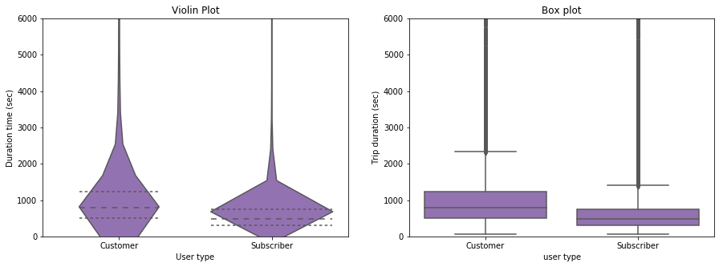

```python
#ploting the violin and box plot to show the relationship between duration time (sec) and type of user.
color=sb.color_palette()[4]
plt.figure(figsize=(15,5))
plt.subplot(1,2,1)
sb.violinplot(df['user_type'], df['duration_sec'], color=color, inner='quartile')
m_n_p('User type', 'Duration time (sec)', 'Violin Plot')
plt.ylim(0, 6000)

plt.subplot(1,2,2)
sb.boxplot(df['user_type'], df['duration_sec'], color=color)
m_n_p('user type', 'Trip duration (sec)', 'Box plot')
plt.ylim(0, 6000)
plt.show()
```

## (Visualization 3)

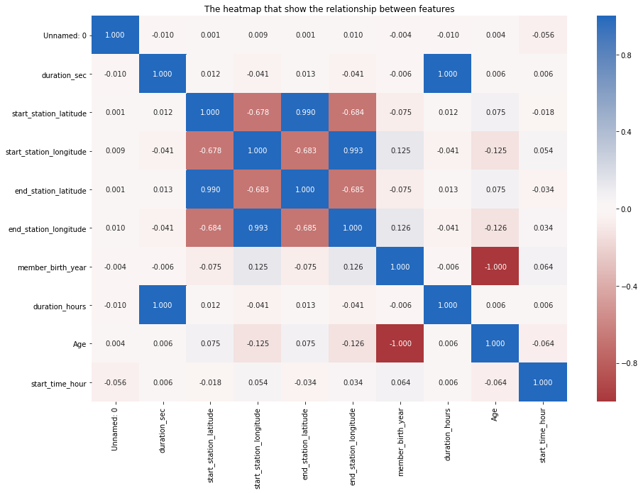

```python
#The correlation of heatmap of df data for numerics features.
plt.figure(figsize = [15, 10])
sb.heatmap(data=df.corr(), annot = True, fmt = '.3f',
           cmap = 'vlag_r', center = 0)
m_n_p('', '', 'The heatmap that show the relationship between features')
plt.show()
```